## Analysis of Suicide Rates

Using the database I have found about suicides internationally with consideration to multiple factors, I want to find out: What are good predictors for suicide rates? Identifying the factors of individuals which contribute to probability of suicide is important to help address the problem on a large scale. It serves as an indicator about what to look at which may be causing increased likelyhood of suicidal tendencies.

```r
library(dplyr)
library(readr)
suicides_db <- read_csv("~/R/Files/suicide.csv") %>%
  rename(suicides_per_100k='suicides/100k pop', gdp='gdp_for_year ($)', gdp_per_capita='gdp_per_capita ($)')%>%
  select(country, year, sex, age, suicides_no, population, suicides_per_100k, gdp, gdp_per_capita, generation)
suicides_db
```

```
## # A tibble: 27,820 x 10
##    country  year sex   age   suicides_no population suicides_per_10~    gdp
##    <chr>   <dbl> <chr> <chr>       <dbl>      <dbl>            <dbl>  <dbl>
##  1 Albania  1987 male  15-2~          21     312900             6.71 2.16e9
##  2 Albania  1987 male  35-5~          16     308000             5.19 2.16e9
##  3 Albania  1987 fema~ 15-2~          14     289700             4.83 2.16e9
##  4 Albania  1987 male  75+ ~           1      21800             4.59 2.16e9
##  5 Albania  1987 male  25-3~           9     274300             3.28 2.16e9
##  6 Albania  1987 fema~ 75+ ~           1      35600             2.81 2.16e9
##  7 Albania  1987 fema~ 35-5~           6     278800             2.15 2.16e9
##  8 Albania  1987 fema~ 25-3~           4     257200             1.56 2.16e9
##  9 Albania  1987 male  55-7~           1     137500             0.73 2.16e9
## 10 Albania  1987 fema~ 5-14~           0     311000             0    2.16e9
## # ... with 27,810 more rows, and 2 more variables: gdp_per_capita <dbl>,
## #   generation <chr>
```

I start by loading this dataset using the read_csv function to use a database I found on Kaggle. In order to tidy it up, I eliminated unecessary attributes like “HDI” which was mostly Null values and did not provide much for analysis, as well as the “country-year” column which was redundant and unecessary for my analysis.

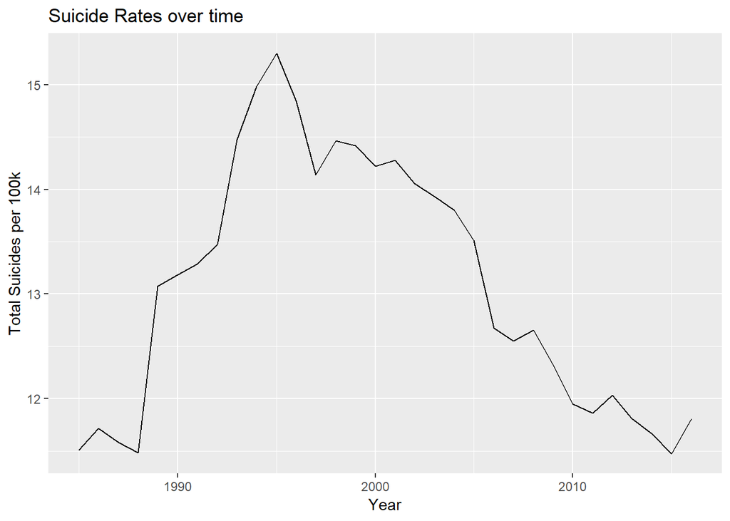

```r
library(ggplot2)
suicides_db %>%
  group_by(year)%>%
  summarize(total_suicides=sum(suicides_no), total_pop=sum(population))%>%
  mutate(suicides_per_100k=(total_suicides*100000)/total_pop)%>%
  ggplot(aes(x=year, y=suicides_per_100k)) +
    geom_line() +
    labs(title="Suicide Rates over time",
         x = "Year",
         y = "Total Suicides per 100k")
```

First, I have a basic plot showing the total suicides over time in order to observe where suicide rates peaked. I do this by grouping the database by year, summing the suicide number and the populations and then using those values to get each year’s total suicides per 100k people. Then I used a line graph to show the progression of suicide rates over time

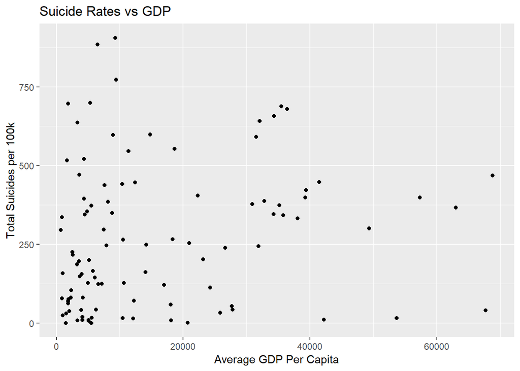

```r
suicides_db %>%
  group_by(country, year)%>%
  summarize(yearly_population=sum(population), yearly_suicides=sum(suicides_no), gdp_per_capita=mean(gdp_per_capita))%>%
  group_by(country)%>%
  summarize(average_population=mean(yearly_population), total_suicides=sum(yearly_suicides), average_gdp_percap=mean(gdp_per_capita)) %>%
  mutate(suicides_per_100k=(total_suicides*100000)/average_population) %>%
  ggplot(aes(x=average_gdp_percap, y=suicides_per_100k)) +
    geom_point() +
    labs(title="Suicide Rates vs GDP",
         x = "Average GDP Per Capita",
         y = "Total Suicides per 100k")
```

I also observed how GDP relates to suicide rates. This was done by first grouping by both country and year in order to get the correct gdp per capita. Then I grouped by country and did the average GDP of that country and found the total suicides per 100k people and graphed that on a scatter plot vs GDP.

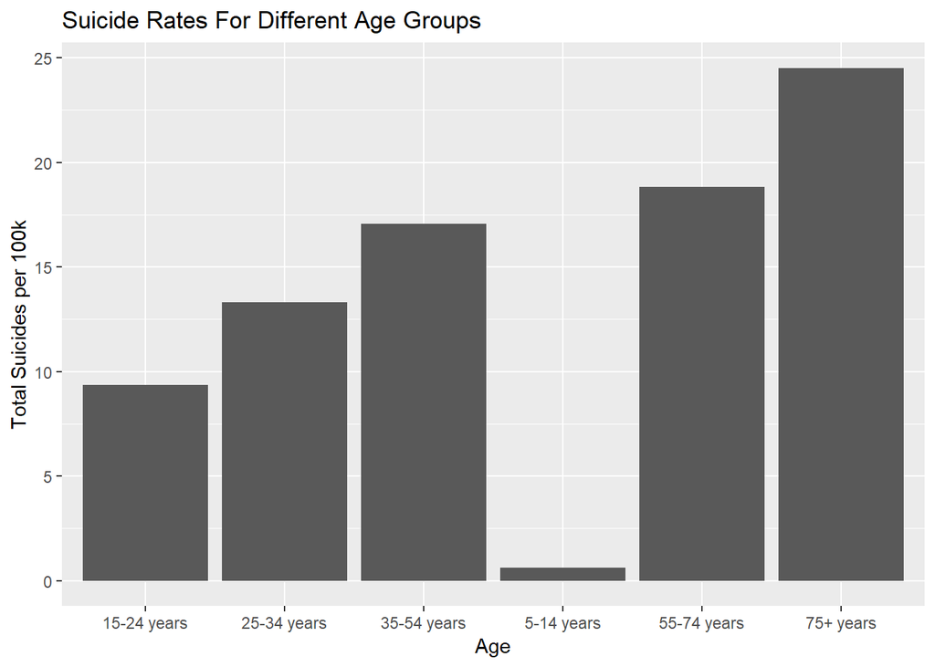

```r
library(ggplot2)
suicides_db %>%
  group_by(age)%>%
  summarize(total_suicides=sum(suicides_no), total_pop=sum(population))%>%
  mutate(suicides_per_100k=(total_suicides*100000)/total_pop)%>%
  ggplot(aes(x=age, y=suicides_per_100k)) +
    geom_bar(stat = "identity") +
    labs(title="Suicide Rates For Different Age Groups",
         x = "Age",
         y = "Total Suicides per 100k")
```

Next, I observed how age relates to suicide rates by reproducing the group by function that I did for suicide rates per year except with age. When graphing it, I used a bar graph to show how each group related to the data.

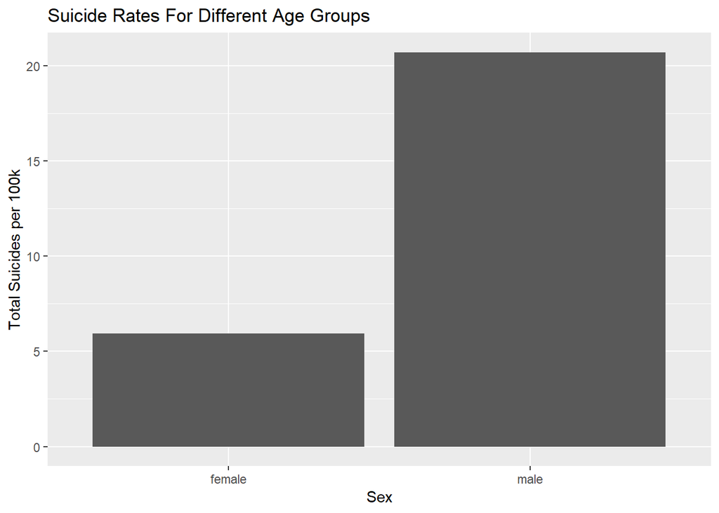

```r
library(ggplot2)
suicides_db %>%
  group_by(sex)%>%
  summarize(total_suicides=sum(suicides_no), total_pop=sum(population))%>%
  mutate(suicides_per_100k=(total_suicides*100000)/total_pop)%>%
  ggplot(aes(x=sex, y=suicides_per_100k)) +
    geom_bar(stat = "identity") +
    labs(title="Suicide Rates For Different Age Groups",
         x = "Sex",
         y = "Total Suicides per 100k")
```

Finally, I followed the same procedure as the last step, except with sex instead of age. You can find more information about suicide rates in reation to sex here: https://afsp.org/about-suicide/suicide-statistics/ .

```r
library(broom)
lm(suicides_no~sex+age+gdp_per_capita, data=suicides_db)%>%
  tidy()
```

```
## # A tibble: 8 x 5
##   term             estimate std.error statistic   p.value
##   <chr>               <dbl>     <dbl>     <dbl>     <dbl>
## 1 (Intercept)      -5.60    14.7         -0.382 7.02e-  1
## 2 sexmale         261.      10.5         24.9   7.28e-135
## 3 age25-34 years   67.9     18.2          3.74  1.86e-  4
## 4 age35-54 years  354.      18.2         19.5   5.66e- 84
## 5 age5-14 years  -163.      18.2         -8.93  4.33e- 19
## 6 age55-74 years  183.      18.2         10.1   7.90e- 24
## 7 age75+ years    -33.5     18.2         -1.84  6.54e-  2
## 8 gdp_per_capita    0.00292  0.000278    10.5   8.24e- 26
```

From this, I learn that age above 75 is not a good indicator of suicide rates, and therefore the formula would be $y=-5.602+260.9*sexmale-162.7*(age5-14)+67.94*(age25-34)+354.1*(age35-54)+183.1*(age55-74)+.002922*gdp\_per\_capita$. I chose this because for all the predictors except age, pvalue was less than 0.05.